# Métodos y simulación estadística Actividad 2 - Caso propiedades de los estimadores: Ejercicio 2

David Aguilar y Christian Bermúdez.

10/03/2024

**Nota: Documento académico para la Maestría en ciencia de datos de la Universidad Javeriana de Cali**

# 1 Enunciado

Sean $X_1$, $X_2$, $X_3$ y $X_4$, una muestra aleatoria de tamaño n=4 cuya población la conforma una distribución exponencial con parámetro $θ$ desconocido. Determine las características de cada uno de los siguientes estimadores propuestos:

$$\hat{\theta}_1 = \frac{X_1 + X_2}{6} + \frac{X_3 + X_4}{3}$$

$$\hat{\theta}_2 = \frac{X_1 + 2X_2 + 3X_3 + 4X_4}{5}$$

$$\hat{\theta}_3 = \frac{X_1 + X_2 + X_3 + X_4}{4}$$

$$\hat{\theta}_4 = \frac{\min\{X_1, X_2, X_3, X_4\} + \max\{X_1, X_2, X_3,
X_4\}}{2}$$

# 2 Respuesta

Respuesta:

```r
#Genero la matriz con 4 datos aleatorios provenientes de una función exponencial con tasa 1
n=1000   #  numero de columnas (tamaño máximo de muestra)
m=4*n #porque necesito cuatro valores
X=matrix(rexp(m,1),ncol=n)
```

*Definimos la función para calcular los estimadores*

```r
# Función para calcular los estimadores para una columna
calcular_los_estimadores <- function(column) {
  estimador_1 <- (column[1] + column[2]) / 6 + (column[3] + column[4]) / 3
  estimador_2 <- (column[1] + 2 * column[2] + 3 * column[3] + 4 * column[4]) / 5
  estimador_3 <- sum(column[1:4]) / 4
  estimador_4 <- (min(column[1:4]) + max(column[1:4])) / 2
  return(c(estimador_1, estimador_2, estimador_3, estimador_4))
}
```

## 2.1 caso n = 20

Se toman 20 resultados de cada estimador

```r
# Extraemos las primeras n columnas
X20 <- X[, 1:20]

# Aplicamos la función a cada columna de X20
estimadores <- apply(X20, 2, calcular_los_estimadores) #l 2 es porque tomo columna, 1 sería fila

# Convertimos el resultado en un data.frame
estimadores_en_df <- data.frame(t(estimadores)) #los voltea y vuelve cada resultado una variable
colnames(estimadores_en_df) <- c('estimador_1', 'estimador_2', 'estimador_3', 'estimador_4')

estimadores_en_df
```

| estimador_1 | estimador_2 | estimador_3 | estimador_4 |
| --- | --- | --- | --- |
| 1.5808004 | 3.1604380 | 1.5507989 | 1.5837073 |
| 1.7024046 | 3.1276754 | 2.1847817 | 1.9743242 |
| 0.6356075 | 1.4164027 | 0.5335567 | 0.7944749 |
| 2.1062764 | 4.4967979 | 1.6387261 | 1.8533296 |
| 0.5667770 | 0.9000184 | 0.8032546 | 1.1506159 |
| 0.7049736 | 1.4904655 | 0.6636023 | 0.6956420 |
| 1.2395589 | 2.1248392 | 1.5050340 | 2.1252556 |
| 3.5792107 | 6.5539727 | 3.6044129 | 3.5288064 |
| 0.3821379 | 0.8863709 | 0.5167510 | 0.9031405 |
| 1.0937162 | 2.3508573 | 1.1328556 | 1.0154376 |

[output cut: 10 more lines]

*Distribución de los datos en un boxplot*

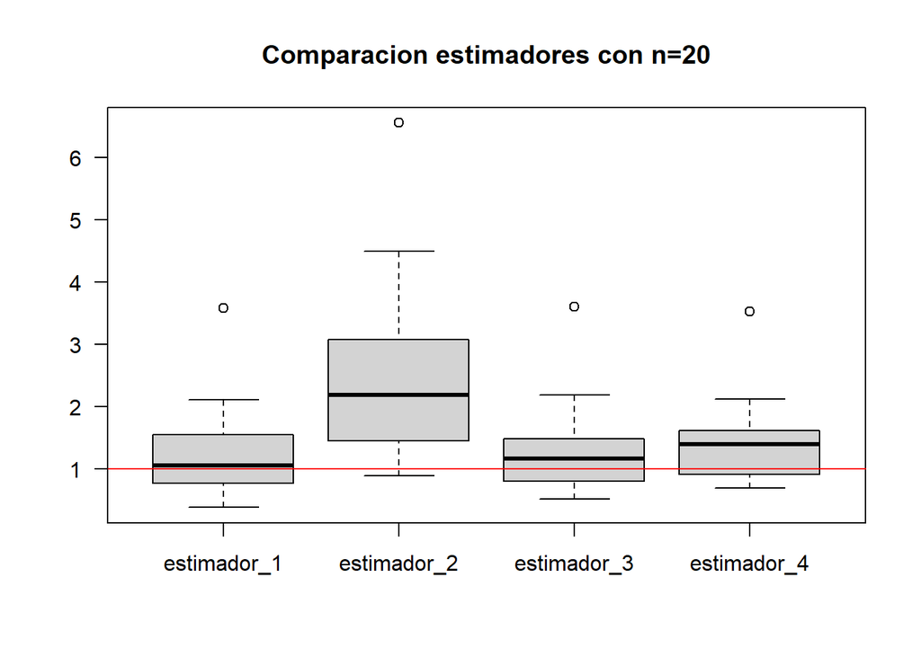

```r
boxplot(estimadores_en_df, las=1, main="Comparacion estimadores con n=20")
abline(h=1,  col="red")
```

*Media y desviación estándar de los estimadores*

```r
#Media
medias <- apply(estimadores_en_df,2,mean)

print(medias)
```

```
## estimador_1 estimador_2 estimador_3 estimador_4
##    1.239936    2.423630    1.242696    1.420158
```

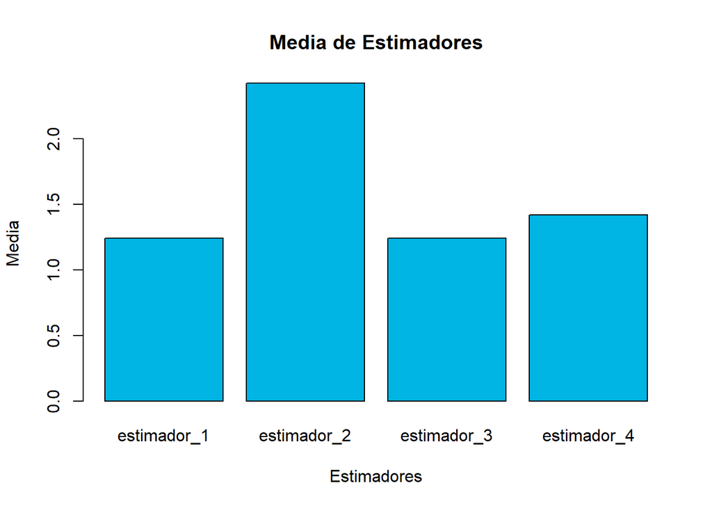

```r
#Grafiquito medias
barplot(medias,
        main = "Media de Estimadores",
        xlab = "Estimadores",
        ylab = "Media",
        col = "#00B4E3",
        names.arg = colnames(estimadores_en_df))
```

```r
#Desviación estándar
devest <- apply(estimadores_en_df,2,sd)

print(devest)
```

```
## estimador_1 estimador_2 estimador_3 estimador_4
##   0.7092956   1.3442056   0.7034250   0.6537572
```

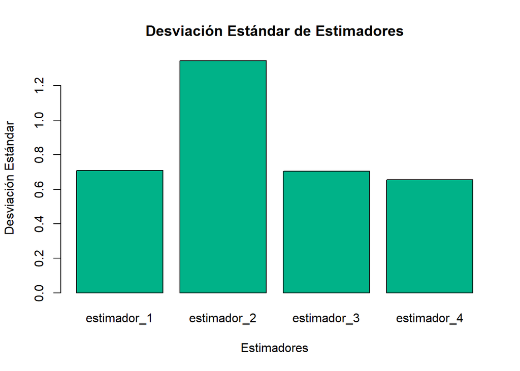

```r
barplot(devest,
        main = "Desviación Estándar de Estimadores",
        xlab = "Estimadores",
        ylab = "Desviación Estándar",
        col = "#00B288",
        names.arg = colnames(estimadores_en_df))
```

Sobre el sesgo vamos a comparar la diferencia entre el valor esperado del estimador theta y el valor verdadero del parámetro, se selecciona el valor de 1 como el valor que debería tomar los estimadores

$B(\hat{\theta}) = E(\hat{\theta}) - \theta$

A continuación, se mira la diferencia (o sesgo) para cada grupo de medias.

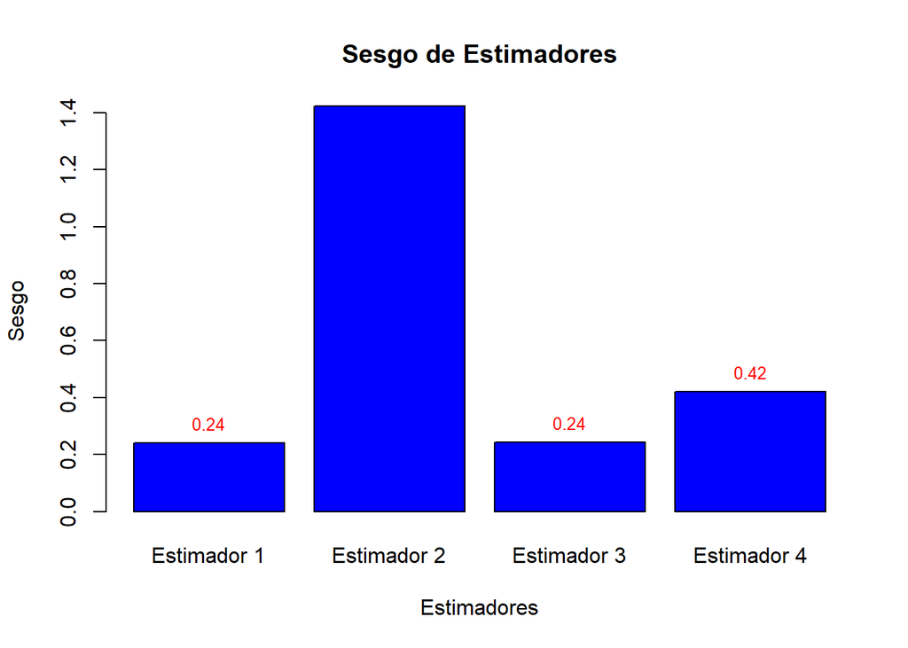

```r
medias <- apply(estimadores_en_df, 2, mean)
# El valor del parámetro es 1
theta <- 1

# Calculamos el sesgo para cada estimador
sesgos <- medias - theta

# Ahora graficamos los sesgos en una gráfica de barras
plotsesgos <- barplot(sesgos,
        main = "Sesgo de Estimadores",
        xlab = "Estimadores",
        ylab = "Sesgo",
        col = "blue",
        names.arg = c("Estimador 1", "Estimador 2", "Estimador 3", "Estimador 4"))


# Agregar etiquetas
text(x = plotsesgos, y = sesgos, label = round(sesgos, 2), pos = 3, cex = 0.8, col = "red")
```

## 2.2 caso n = 50

Se toman 50 resultados de cada estimador

```r
# Extraemos las primeras n columnas
X50 <- X[, 1:50]

# Aplicamos la función a cada columna de X20
estimadores <- apply(X50, 2, calcular_los_estimadores) #l 2 es porque tomo columna, 1 sería fila

# Convertimos el resultado en un data.frame
estimadores_en_df <- data.frame(t(estimadores)) #los voltea y vuelve cada resultado una variable
colnames(estimadores_en_df) <- c('estimador_1', 'estimador_2', 'estimador_3', 'estimador_4')

estimadores_en_df
```

| estimador_1 | estimador_2 | estimador_3 | estimador_4 |
| --- | --- | --- | --- |
| 1.5808004 | 3.1604380 | 1.5507989 | 1.5837073 |
| 1.7024046 | 3.1276754 | 2.1847817 | 1.9743242 |
| 0.6356075 | 1.4164027 | 0.5335567 | 0.7944749 |
| 2.1062764 | 4.4967979 | 1.6387261 | 1.8533296 |
| 0.5667770 | 0.9000184 | 0.8032546 | 1.1506159 |
| 0.7049736 | 1.4904655 | 0.6636023 | 0.6956420 |
| 1.2395589 | 2.1248392 | 1.5050340 | 2.1252556 |
| 3.5792107 | 6.5539727 | 3.6044129 | 3.5288064 |
| 0.3821379 | 0.8863709 | 0.5167510 | 0.9031405 |
| 1.0937162 | 2.3508573 | 1.1328556 | 1.0154376 |

[output cut: 40 more lines]

*Distribución de los datos en un boxplot*

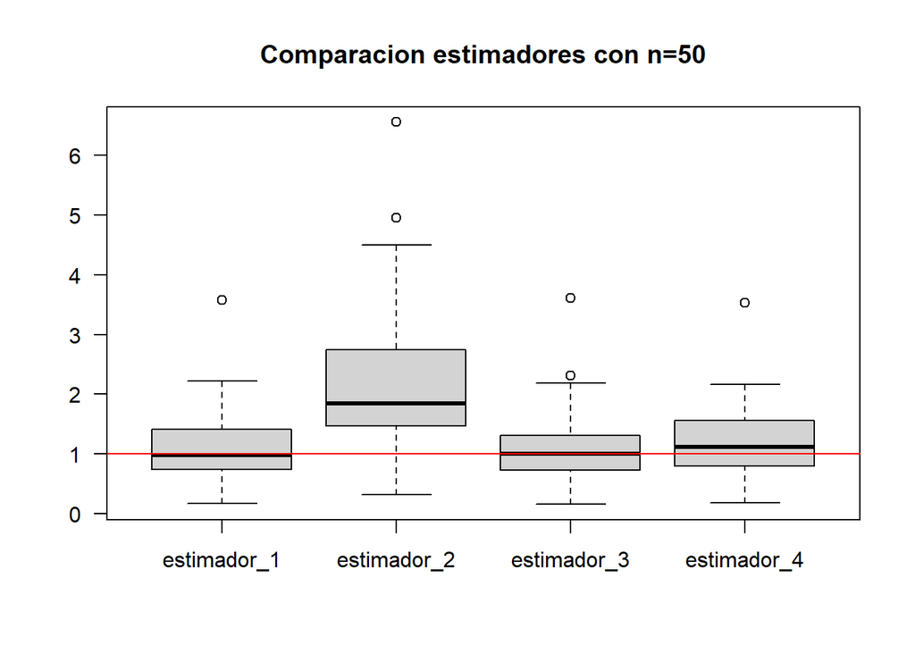

```r
boxplot(estimadores_en_df, las=1, main="Comparacion estimadores con n=50")
abline(h=1,  col="red")
```

*Media y desviación estándar de los estimadores*

```r
#Media
medias <- apply(estimadores_en_df,2,mean)

print(medias)
```

```
## estimador_1 estimador_2 estimador_3 estimador_4
##    1.100226    2.201816    1.090622    1.228927
```

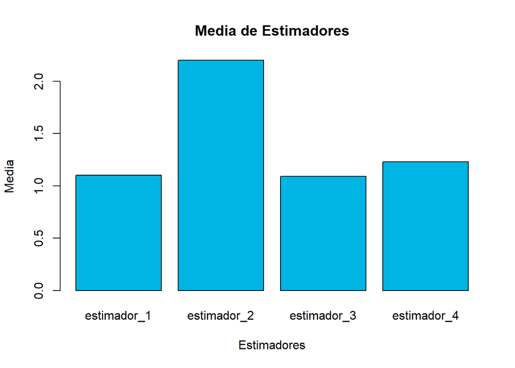

```r
#Grafiquito medias
barplot(medias,
        main = "Media de Estimadores",
        xlab = "Estimadores",
        ylab = "Media",
        col = "#00B4E3",
        names.arg = colnames(estimadores_en_df))
```

```r
#Desviación estándar
devest <- apply(estimadores_en_df,2,sd)

print(devest)
```

```
## estimador_1 estimador_2 estimador_3 estimador_4
##   0.5869309   1.1685774   0.5686657   0.5818556
```

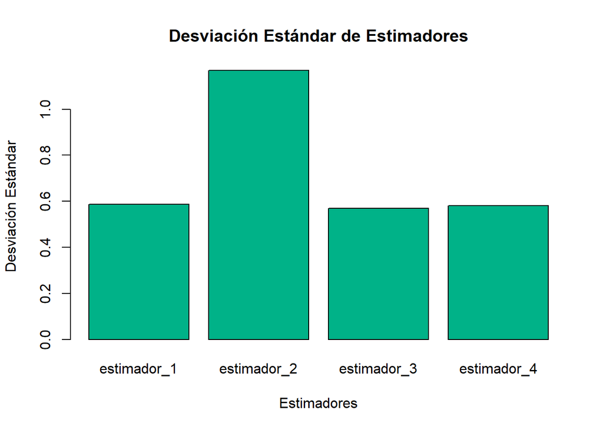

```r
barplot(devest,
        main = "Desviación Estándar de Estimadores",
        xlab = "Estimadores",
        ylab = "Desviación Estándar",
        col = "#00B288",
        names.arg = colnames(estimadores_en_df))
```

Sobre el sesgo vamos a comparar la diferencia entre el valor esperado del estimador theta y el valor verdadero del parámetro, se selecciona el valor de 1 como el valor que debería tomar los estimadores

$B(\hat{\theta}) = E(\hat{\theta}) - \theta$

A continuación, se mira la diferencia (o sesgo) para cada grupo de medias.

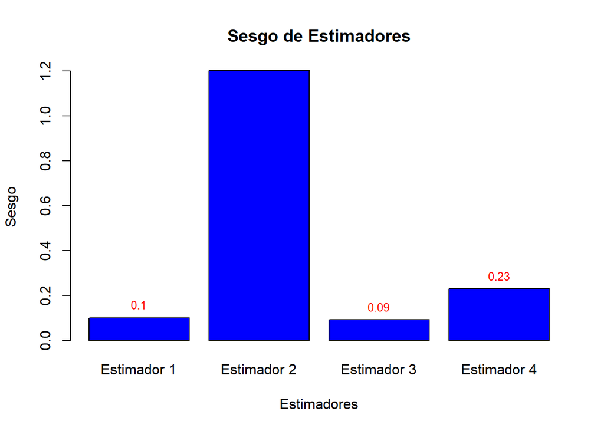

```r
medias <- apply(estimadores_en_df, 2, mean)
# El valor del parámetro es 1
theta <- 1

# Calculamos el sesgo para cada estimador
sesgos <- medias - theta

# Ahora graficamos los sesgos en una gráfica de barras
plotsesgos <- barplot(sesgos,
        main = "Sesgo de Estimadores",
        xlab = "Estimadores",
        ylab = "Sesgo",
        col = "blue",
        names.arg = c("Estimador 1", "Estimador 2", "Estimador 3", "Estimador 4"))


# Agregar etiquetas
text(x = plotsesgos, y = sesgos, label = round(sesgos, 2), pos = 3, cex = 0.8, col = "red")
```

## 2.3 caso n = 100

Se toman 100 resultados de cada estimador

```r
# Extraemos las primeras n columnas
X100 <- X[, 1:100]

# Aplicamos la función a cada columna de X20
estimadores <- apply(X100, 2, calcular_los_estimadores) #l 2 es porque tomo columna, 1 sería fila

# Convertimos el resultado en un data.frame
estimadores_en_df <- data.frame(t(estimadores)) #los voltea y vuelve cada resultado una variable
colnames(estimadores_en_df) <- c('estimador_1', 'estimador_2', 'estimador_3', 'estimador_4')

estimadores_en_df
```

| estimador_1 | estimador_2 | estimador_3 | estimador_4 |
| --- | --- | --- | --- |
| 1.5808004 | 3.1604380 | 1.5507989 | 1.5837073 |
| 1.7024046 | 3.1276754 | 2.1847817 | 1.9743242 |
| 0.6356075 | 1.4164027 | 0.5335567 | 0.7944749 |
| 2.1062764 | 4.4967979 | 1.6387261 | 1.8533296 |
| 0.5667770 | 0.9000184 | 0.8032546 | 1.1506159 |
| 0.7049736 | 1.4904655 | 0.6636023 | 0.6956420 |
| 1.2395589 | 2.1248392 | 1.5050340 | 2.1252556 |
| 3.5792107 | 6.5539727 | 3.6044129 | 3.5288064 |
| 0.3821379 | 0.8863709 | 0.5167510 | 0.9031405 |
| 1.0937162 | 2.3508573 | 1.1328556 | 1.0154376 |

[output cut: 90 more lines]

*Distribución de los datos en un boxplot*

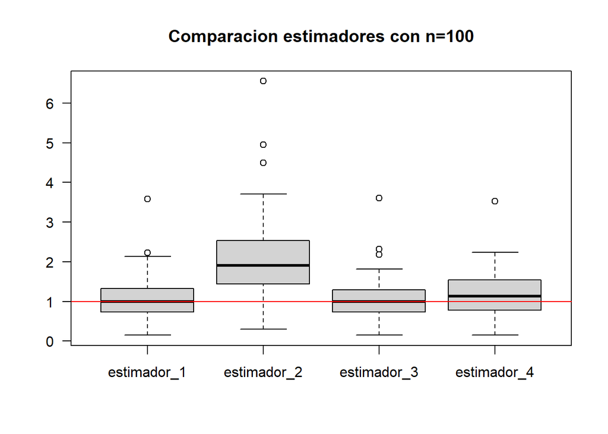

```r
boxplot(estimadores_en_df, las=1, main="Comparacion estimadores con n=100")
abline(h=1,  col="red")
```

*Media y desviación estándar de los estimadores*

```r
#Media
medias <- apply(estimadores_en_df,2,mean)

print(medias)
```

```
## estimador_1 estimador_2 estimador_3 estimador_4
##    1.043835    2.087945    1.044891    1.192165
```

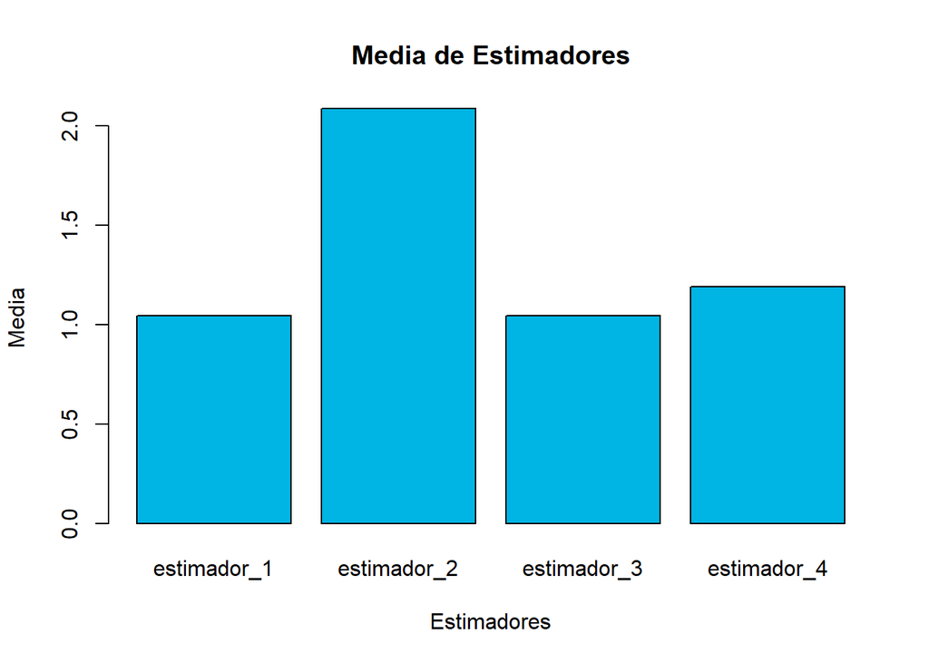

```r
#Grafiquito medias
barplot(medias,
        main = "Media de Estimadores",
        xlab = "Estimadores",
        ylab = "Media",
        col = "#00B4E3",
        names.arg = colnames(estimadores_en_df))
```

```r
#Desviación estándar
devest <- apply(estimadores_en_df,2,sd)

print(devest)
```

```
## estimador_1 estimador_2 estimador_3 estimador_4
##   0.5015771   1.0248350   0.4939289   0.5379408
```

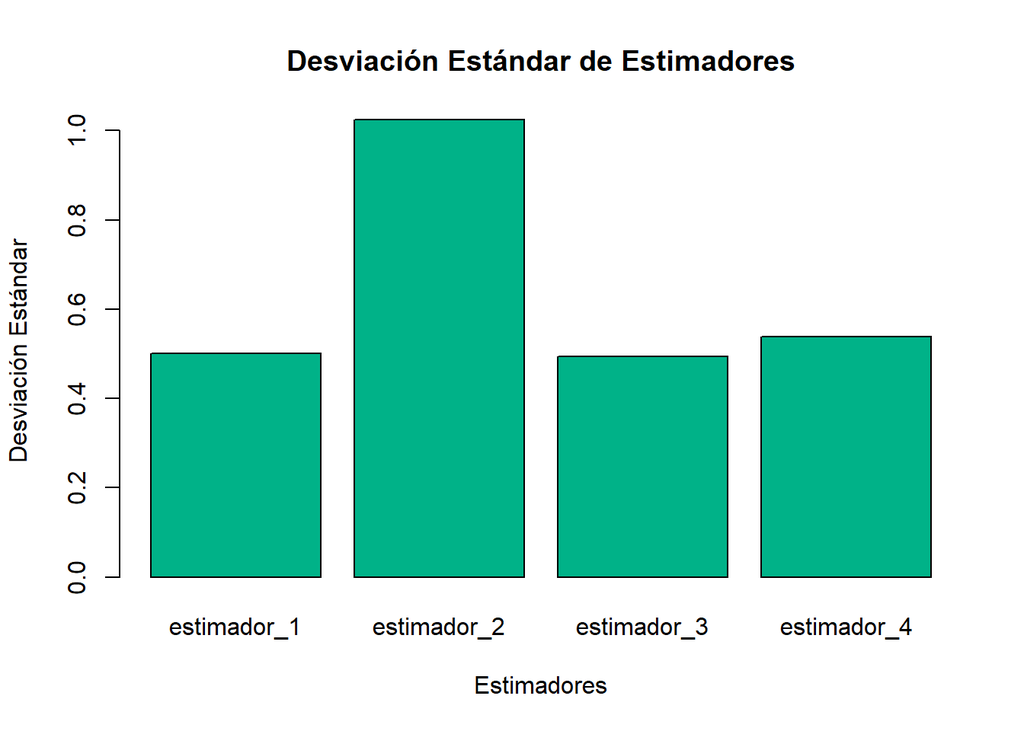

```r
barplot(devest,
        main = "Desviación Estándar de Estimadores",
        xlab = "Estimadores",
        ylab = "Desviación Estándar",
        col = "#00B288",
        names.arg = colnames(estimadores_en_df))
```

Sobre el sesgo vamos a comparar la diferencia entre el valor esperado del estimador theta y el valor verdadero del parámetro, se selecciona el valor de 1 como el valor que debería tomar los estimadores

$B(\hat{\theta}) = E(\hat{\theta}) - \theta$

A continuación, se mira la diferencia (o sesgo) para cada grupo de medias.

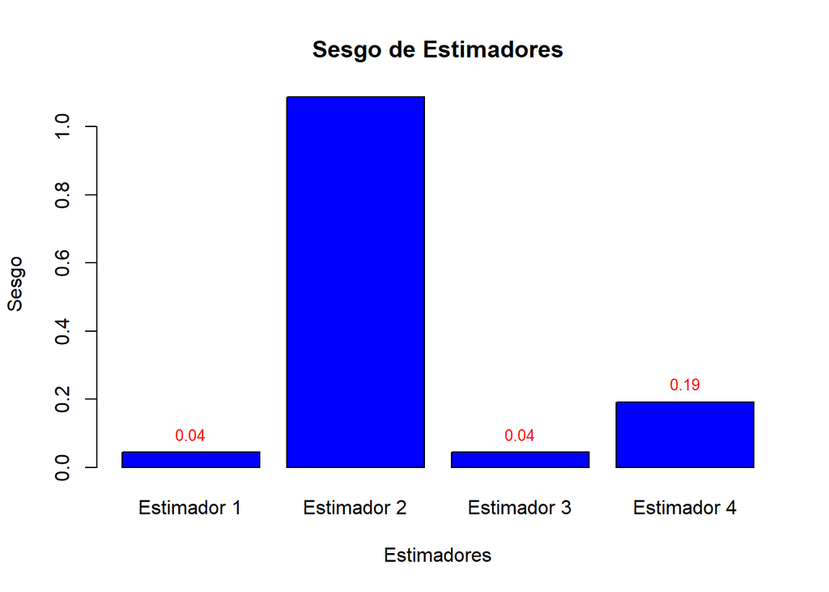

```r
medias <- apply(estimadores_en_df, 2, mean)
# El valor del parámetro es 1
theta <- 1

# Calculamos el sesgo para cada estimador
sesgos <- medias - theta

# Ahora graficamos los sesgos en una gráfica de barras
plotsesgos <- barplot(sesgos,
        main = "Sesgo de Estimadores",
        xlab = "Estimadores",
        ylab = "Sesgo",
        col = "blue",
        names.arg = c("Estimador 1", "Estimador 2", "Estimador 3", "Estimador 4"))


# Agregar etiquetas
text(x = plotsesgos, y = sesgos, label = round(sesgos, 2), pos = 3, cex = 0.8, col = "red")
```

## 2.4 caso n = 1000

```r
# Extraemos las primeras n columnas
X1000 <- X[, 1:1000]

# Aplicamos la función a cada columna de X20
estimadores <- apply(X1000, 2, calcular_los_estimadores) #l 2 es porque tomo columna, 1 sería fila

# Convertimos el resultado en un data.frame
estimadores_en_df <- data.frame(t(estimadores)) #los voltea y vuelve cada resultado una variable
colnames(estimadores_en_df) <- c('estimador_1', 'estimador_2', 'estimador_3', 'estimador_4')

estimadores_en_df
```

| estimador_1 | estimador_2 | estimador_3 | estimador_4 |
| --- | --- | --- | --- |
| 1.58080039 | 3.16043804 | 1.55079889 | 1.5837073 |
| 1.70240462 | 3.12767543 | 2.18478167 | 1.9743242 |
| 0.63560751 | 1.41640266 | 0.53355666 | 0.7944749 |
| 2.10627641 | 4.49679792 | 1.63872609 | 1.8533296 |
| 0.56677698 | 0.90001840 | 0.80325456 | 1.1506159 |
| 0.70497362 | 1.49046550 | 0.66360231 | 0.6956420 |
| 1.23955891 | 2.12483916 | 1.50503400 | 2.1252556 |
| 3.57921072 | 6.55397270 | 3.60441289 | 3.5288064 |
| 0.38213788 | 0.88637089 | 0.51675104 | 0.9031405 |
| 1.09371623 | 2.35085730 | 1.13285555 | 1.0154376 |

[output cut: 990 more lines]

*Distribución de los datos en un boxplot*

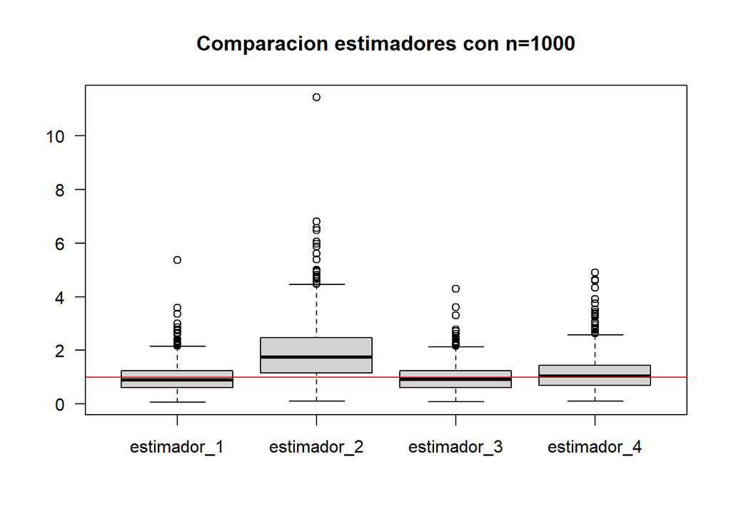

```r
boxplot(estimadores_en_df, las=1, main="Comparacion estimadores con n=1000")
abline(h=1,  col="red")
```

*Media y desviación estándar de los estimadores*

```r
#Media
medias <- apply(estimadores_en_df,2,mean)

print(medias)
```

```
## estimador_1 estimador_2 estimador_3 estimador_4
##    0.966459    1.920833    0.976204    1.132399
```

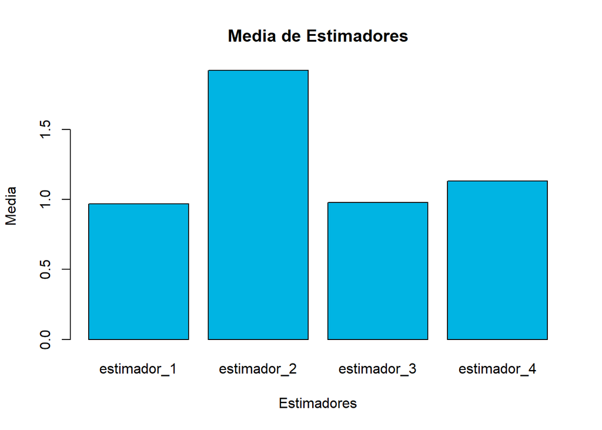

```r
#Grafiquito medias
barplot(medias,
        main = "Media de Estimadores",
        xlab = "Estimadores",
        ylab = "Media",
        col = "#00B4E3",
        names.arg = colnames(estimadores_en_df))
```

```r
#Desviación estándar
devest <- apply(estimadores_en_df,2,sd)

print(devest)
```

```
## estimador_1 estimador_2 estimador_3 estimador_4
##   0.5149450   1.0470881   0.4934050   0.6272469
```

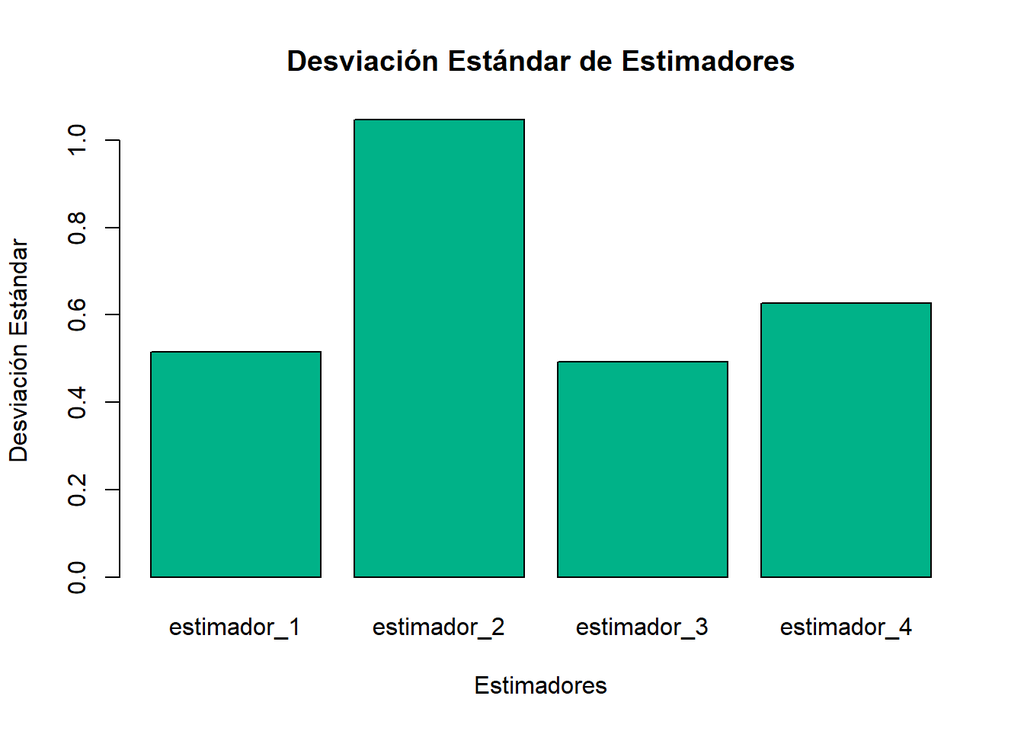

```r
barplot(devest,
        main = "Desviación Estándar de Estimadores",
        xlab = "Estimadores",
        ylab = "Desviación Estándar",
        col = "#00B288",
        names.arg = colnames(estimadores_en_df))
```

Sobre el sesgo vamos a comparar la diferencia entre el valor esperado del estimador theta y el valor verdadero del parámetro, se selecciona el valor de 1 como el valor que debería tomar los estimadores

$B(\hat{\theta}) = E(\hat{\theta}) - \theta$

A continuación, se mira la diferencia (o sesgo) para cada grupo de medias.

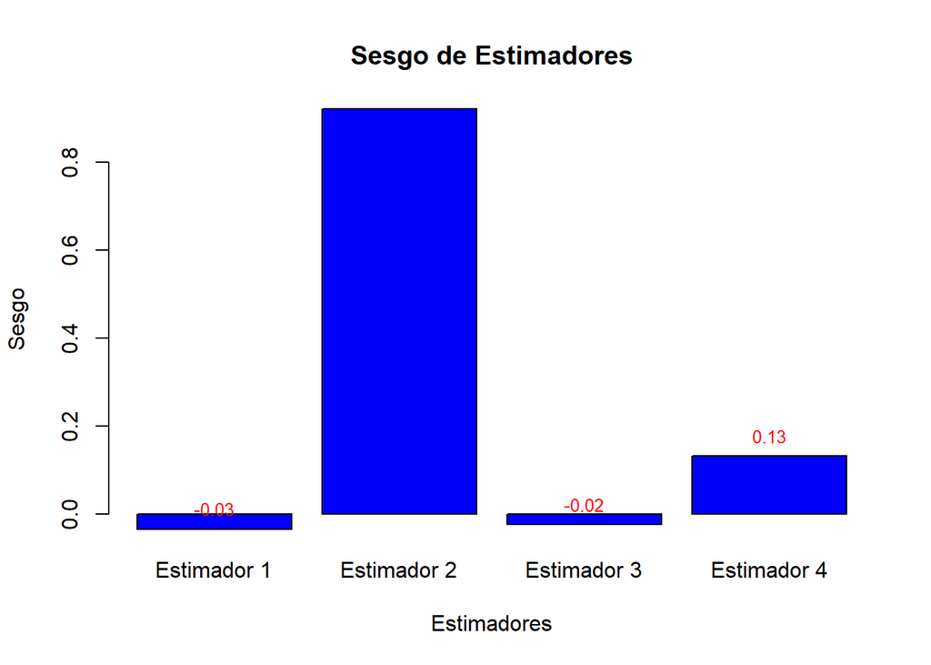

```r
medias <- apply(estimadores_en_df, 2, mean)
# El valor del parámetro es 1
theta <- 1

# Calculamos el sesgo para cada estimador
sesgos <- medias - theta

# Ahora graficamos los sesgos en una gráfica de barras
plotsesgos <- barplot(sesgos,
        main = "Sesgo de Estimadores",
        xlab = "Estimadores",
        ylab = "Sesgo",
        col = "blue",
        names.arg = c("Estimador 1", "Estimador 2", "Estimador 3", "Estimador 4"))


# Agregar etiquetas
text(x = plotsesgos, y = sesgos, label = round(sesgos, 2), pos = 3, cex = 0.8, col = "red")
```

**Fin del documento**

[figure not shown]